# Supporting Material: Environmental Chemicals as Modifiers of the Association between Chronological Age and Ovarian Reserve

- Show All Code
- Hide All Code
- View Source

Author

Affiliation

Ashley I Naimi

Emory University

Published

October 9, 2026

# 1 Introduction

This report is the online supporting material for *Environmental Chemicals as Modifiers of the Association between Chronological Age and Ovarian Reserve* (Naimi, Kennedy, Yu, Hauser, Mínguez-Alarcón, Gaskins). It presents the complete analysis pipeline for examining whether and how environmental endocrine disrupting chemicals (EDCs) modify the association between age and antral follicle count (AFC) in women from the EARTH Study. The code that produced every table and figure is available at https://github.com/ainaimi/EARTH_Analysis.

**Study population:** 775 women enrolled in the EARTH Study (2004-2019), each contributing one AFC measurement. Age at the AFC scan ranged from 21 to 46 years and was dichotomized at 35 years (≥35 vs <35).

**Candidate modifiers:** 16 chemicals: 11 urinary phthalate metabolites, 3 urinary parabens, urinary bisphenol A, and hair mercury.

**Method:** the doubly robust (DR) learner. Cross-validated Super Learner fits of the outcome regression and the propensity score are combined into an augmented inverse probability weighted (AIPW) score for each woman. The mean of the scores estimates the covariate-standardized mean difference in AFC between women aged ≥35 and <35 years (denoted ψ in the manuscript), and regressing the scores on the chemicals summarizes how that difference varies with chemical concentration (τ(x) in the manuscript).

**Interpretation:** ψ and τ(x) are covariate-standardized *associations*, not causal effects. Age is not a manipulable exposure, the data are cross-sectional, most chemical samples were collected after the AFC scan (see the sample-timing results in Step 0), and several covariates may be intermediates between age and AFC. The DR-learner comes from the heterogeneous-treatment-effect literature, so a few object names in the code and in this report (`ate_results`, “AIPW with Stacking”, `cate_functions_*.png`) retain that vocabulary. They refer to the standardized associational contrasts defined above.

# 2 Step 0: Missing Data Analysis and Imputation

This section summarizes the missing data patterns in the raw EARTH Study data and describes the random forest imputation approach used to handle missingness before analysis.

## 2.1 Missing Data Summary

```r
missing_summary <- readRDS(here("output", "missing_data_summary.rds"))
knitr::kable(missing_summary, caption = "Missing Data Summary by Variable")
```

Missing Data Summary by Variable

| variable | n_missing | pct_missing | n_complete |
| --- | --- | --- | --- |
| BPF | 666 | 85.94 | 109 |
| ipPPP | 610 | 78.71 | 165 |
| BDCIPP | 608 | 78.45 | 167 |
| DPHP | 594 | 76.65 | 181 |
| sgratio_opfr | 579 | 74.71 | 196 |
| BPS | 503 | 64.90 | 272 |
| BP_3 | 318 | 41.03 | 457 |
| TCS | 318 | 41.03 | 457 |
| mCNP | 138 | 17.81 | 637 |
| mCOP | 138 | 17.81 | 637 |
| B_PB | 117 | 15.10 | 658 |
| M_PB | 117 | 15.10 | 658 |
| P_PB | 117 | 15.10 | 658 |
| sgratio_pht | 92 | 11.87 | 683 |
| sgratio_bpa | 92 | 11.87 | 683 |
| mBP | 92 | 11.87 | 683 |
| miBP | 92 | 11.87 | 683 |
| mECPP | 92 | 11.87 | 683 |
| mEHHP | 92 | 11.87 | 683 |
| mEHP | 92 | 11.87 | 683 |
| mEOHP | 92 | 11.87 | 683 |
| mCPP | 92 | 11.87 | 683 |
| mEP1 | 92 | 11.87 | 683 |
| mBZP1 | 92 | 11.87 | 683 |
| dehp | 92 | 11.87 | 683 |
| BPA | 92 | 11.87 | 683 |
| Hg | 84 | 10.84 | 691 |
| previousIUI | 55 | 7.10 | 720 |
| previousIVF | 55 | 7.10 | 720 |
| bmi | 12 | 1.55 | 763 |
| smokstat | 5 | 0.65 | 770 |
| races | 4 | 0.52 | 771 |
| age | 4 | 0.52 | 771 |
| AFScanDate | 2 | 0.26 | 773 |
| educ1 | 1 | 0.13 | 774 |
| gravid | 1 | 0.13 | 774 |
| id | 0 | 0.00 | 775 |
| AFC_t | 0 | 0.00 | 775 |
| sartnew2 | 0 | 0.00 | 775 |

This table shows the extent of missing data for each variable in the raw dataset. Variables with more than 40% missingness were excluded from the analysis (including BPS, BPF, BP3, TCS, and all OPFR metabolites).

## 2.2 Missing Data Visualization

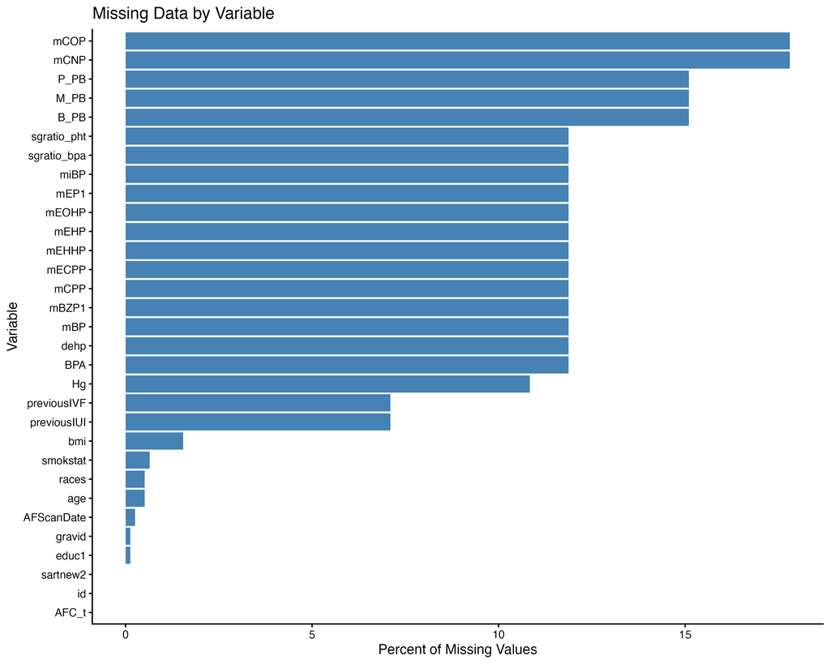

Missing data patterns by variable

This bar chart visualizes the percentage of missing values for each variable, making it easy to identify which variables have substantial missingness.

## 2.3 Distribution Comparison: Original vs Imputed

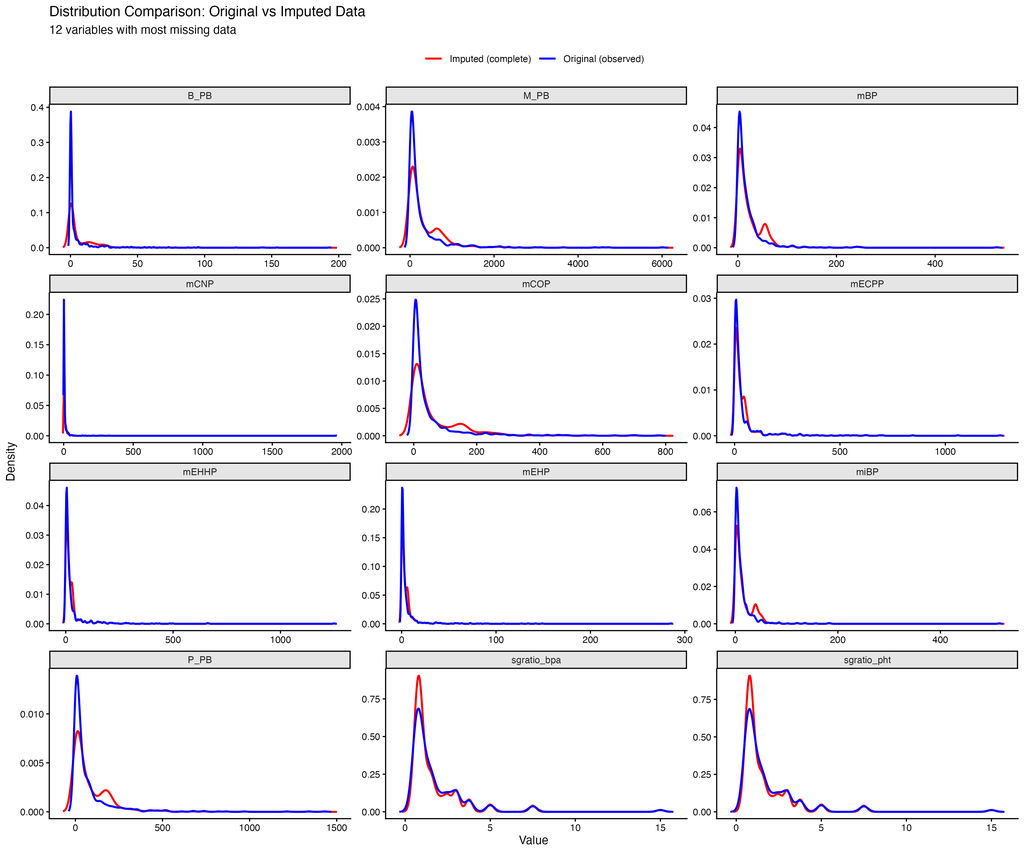

Comparison of distributions before and after imputation

This multi-panel figure compares the distributions of observed data (blue, solid line) versus complete imputed data (red, solid line) for the 12 variables with the most missing values. The similarity between distributions suggests that the random forest imputation preserved the underlying data structure.

## 2.4 Imputation Performance

```r
imputation_error <- readRDS(here("output", "imputation_error.rds"))
knitr::kable(imputation_error, caption = "Random Forest Imputation Out-of-Bag Error Estimates")
```

Random Forest Imputation Out-of-Bag Error Estimates

|  | NRMSE | PFC |
| --- | --- | --- |
| NRMSE | 0.47 | 0.33 |

The out-of-bag (OOB) error estimates provide measures of imputation accuracy. NRMSE (normalized root mean squared error) applies to continuous variables, while PFC (proportion falsely classified) applies to categorical variables. Lower values indicate better imputation performance.

## 2.5 Temporal Relationship Between Measurements

This section examines the timing between environmental exposure measurements and AFC assessment to understand the temporal structure of the data.

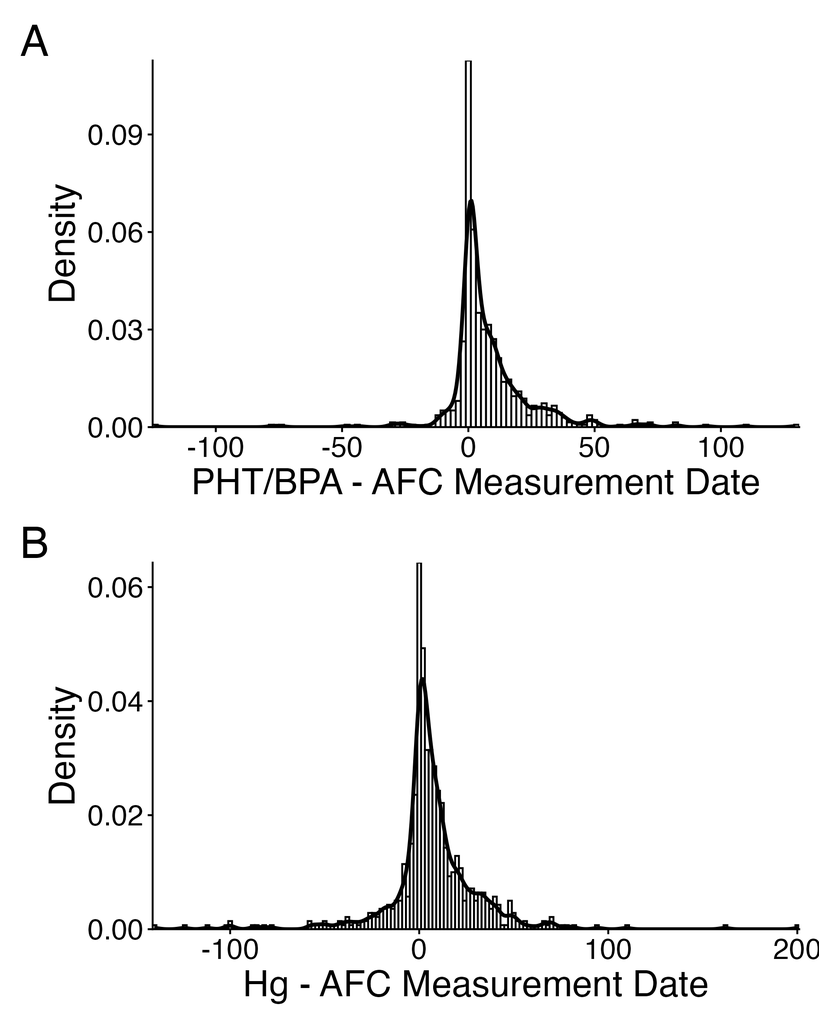

Distribution of time lag between exposure measurements and AFC scan

Panel A shows the distribution of time (in weeks) between when phthalate and BPA samples were collected and when AFC was measured. Panel B shows the distribution for mercury samples. The density overlays help visualize the central tendency and spread of the measurement timing. Comparing the two panels reveals whether different exposure biomarkers were collected on different schedules relative to the AFC assessment.

### 2.5.1 Summary Statistics for Measurement Timing

```r
date_summary <- readRDS(here("output", "date_comparison_summary.rds"))
knitr::kable(date_summary, caption = "Summary Statistics for Time Between Exposure Measurement and AFC Assessment")
```

Summary Statistics for Time Between Exposure Measurement and AFC Assessment

| Variable | Min | 1st Qu | Median | Mean | 3rd Qu | Max |
| --- | --- | --- | --- | --- | --- | --- |
| PHT/BPA to AFC (weeks) | -124 | 0.6 | 4.0 | 8.2 | 12 | 129 |
| Hg to AFC (weeks) | -140 | 0.0 | 4.4 | 6.9 | 15 | 201 |

This table provides summary statistics for the temporal gaps between exposure biomarker collection and AFC measurement. These timing patterns are important for understanding the exposure window being assessed relative to the outcome measurement.

### 2.5.2 Sample Timing Relative to the AFC Scan

Because EARTH participants provided urine and hair samples at study entry and during subsequent treatment cycles, the single sample selected as closest to the AFC assessment could be collected either before or after the scan. The table below reports how many exposure samples fell on each side of the AFC scan.

```r
date_timing_counts <- readRDS(here("output", "date_timing_counts.rds"))
date_timing_display <- data.frame(
  Variable = date_timing_counts$Variable,
  N = date_timing_counts$N,
  `Collected after AFC scan, n (%)`  = sprintf("%d (%.1f%%)", date_timing_counts$n_after,  date_timing_counts$pct_after),
  `Collected before AFC scan, n (%)` = sprintf("%d (%.1f%%)", date_timing_counts$n_before, date_timing_counts$pct_before),
  `Same day, n (%)`                  = sprintf("%d (%.1f%%)", date_timing_counts$n_same,   date_timing_counts$pct_same),
  check.names = FALSE
)
knitr::kable(
  date_timing_display,
  caption = "Number of exposure samples collected before, after, or on the same day as the AFC scan. A sample is classified as collected *after* the scan when its collection date is later than the AFC scan date (equivalently, a negative value of AFC scan date minus sample date)."
)
```

Number of exposure samples collected before, after, or on the same day as the AFC scan. A sample is classified as collected *after* the scan when its collection date is later than the AFC scan date (equivalently, a negative value of AFC scan date minus sample date).

| Variable | N | Collected after AFC scan, n (%) | Collected before AFC scan, n (%) | Same day, n (%) |
| --- | --- | --- | --- | --- |
| PHT/BPA | 683 | 549 (80.4%) | 93 (13.6%) | 41 (6.0%) |
| Hg | 700 | 502 (71.7%) | 165 (23.6%) | 33 (4.7%) |

For most participants, the exposure biomarker was measured *after* the AFC scan: 549 of 683 phthalate/BPA samples (80.4%) and 502 of 700 hair mercury samples (71.7%) were collected after the scan, compared with 13.6% and 23.6% collected before it. This confirms that the closest available sample could fall on either side of the AFC assessment and, in the large majority of cases, was measured shortly afterward.

# 3 Step 1: Data Management and Preprocessing

This section presents summary statistics from the initial data management and preprocessing stage. We examine the distribution of antral follicle count (AFC) by diminished ovarian reserve (DOR) status, overall data quality metrics, and key summary statistics for our analysis variables.

## 3.1 AFC Summary by DOR Status

```r
afc_summary <- readRDS(here("output", "afc_summary_by_DOR.rds"))
knitr::kable(afc_summary, caption = "Summary of AFC by DOR Status")
```

Summary of AFC by DOR Status

| DOR | n() | min(AFCt) | max(AFCt) | mean(AFCt) | median(AFCt) |
| --- | --- | --- | --- | --- | --- |
| 0 | 686 | 2 | 60 | 14.8 | 13 |
| 1 | 89 | 1 | 24 | 6.8 | 6 |

This table summarizes AFC by diminished ovarian reserve (DOR) status, a clinical infertility diagnosis abstracted from the medical record. DOR is shown for description only; it is not used in any of the models below.

## 3.2 Data Quality Assessment

```r
skim_results <- readRDS(here("output", "skim_results.rds"))
skim_results[,-1]
```

| skim_variable | n_missing | complete_rate | factor.ordered | factor.n_unique | factor.top_counts | numeric.mean | numeric.sd | numeric.p0 | numeric.p25 | numeric.p50 | numeric.p75 | numeric.p100 | numeric.hist |
| --- | --- | --- | --- | --- | --- | --- | --- | --- | --- | --- | --- | --- | --- |
| DOR | 0 | 1 | FALSE | 2 | 0: 686, 1: 89 |  |  |  |  |  |  |  |  |
| races | 0 | 1 | FALSE | 4 | 1: 637, 3: 77, 4: 31, 2: 30 |  |  |  |  |  |  |  |  |
| educ1 | 0 | 1 | FALSE | 3 | 2: 401, 1: 319, 0: 55 |  |  |  |  |  |  |  |  |
| smokstat | 0 | 1 | FALSE | 3 | 1: 580, 2: 176, 3: 19 |  |  |  |  |  |  |  |  |
| previousIVF | 0 | 1 | FALSE | 2 | 0: 663, 1: 112 |  |  |  |  |  |  |  |  |
| previousIUI | 0 | 1 | FALSE | 2 | 0: 553, 1: 222 |  |  |  |  |  |  |  |  |
| gravid | 0 | 1 | FALSE | 2 | 0: 425, 1: 350 |  |  |  |  |  |  |  |  |
| AFCt | 0 | 1 |  |  |  | 13.9 | 7.8 | 1.00 | 8.00 | 12.0 | 18.0 | 60 | ▇▆▁▁▁ |
| year | 0 | 1 |  |  |  | 2011.6 | 3.6 | 2004.00 | 2009.00 | 2011.0 | 2015.0 | 2019 | ▃▇▆▆▃ |
| month | 0 | 1 |  |  |  | 6.4 | 3.6 | 1.00 | 3.00 | 6.0 | 10.0 | 12 | ▇▅▃▅▇ |
| age | 0 | 1 |  |  |  | 35.3 | 4.3 | 21.00 | 32.00 | 35.0 | 38.0 | 46 | ▁▃▇▆▂ |
| bmi | 0 | 1 |  |  |  | 24.6 | 4.7 | 16.10 | 21.27 | 23.5 | 26.4 | 54 | ▇▆▂▁▁ |
| MBP | 0 | 1 |  |  |  | 21.4 | 25.4 | 0.42 | 6.44 | 13.6 | 28.4 | 315 | ▇▁▁▁▁ |
| MiBP | 0 | 1 |  |  |  | 14.6 | 20.2 | 0.17 | 4.27 | 8.5 | 18.0 | 322 | ▇▁▁▁▁ |
| MCNP | 0 | 1 |  |  |  | 15.8 | 82.2 | 0.19 | 1.87 | 3.7 | 10.9 | 1633 | ▇▁▁▁▁ |
| MCOP | 0 | 1 |  |  |  | 66.5 | 149.1 | 0.62 | 7.99 | 28.1 | 94.1 | 3585 | ▇▁▁▁▁ |
| MECPP | 0 | 1 |  |  |  | 52.0 | 129.9 | 1.20 | 10.18 | 19.4 | 39.3 | 2109 | ▇▁▁▁▁ |
| MEHHP | 0 | 1 |  |  |  | 33.9 | 101.9 | 0.35 | 5.82 | 12.0 | 25.1 | 1977 | ▇▁▁▁▁ |
| MEHP | 0 | 1 |  |  |  | 7.2 | 21.1 | 0.15 | 1.20 | 2.5 | 5.3 | 267 | ▇▁▁▁▁ |
| MEOHP | 0 | 1 |  |  |  | 21.4 | 63.7 | 0.21 | 3.75 | 7.6 | 17.0 | 1278 | ▇▁▁▁▁ |
| MCPP | 0 | 1 |  |  |  | 9.4 | 34.6 | 0.11 | 1.43 | 3.1 | 10.0 | 758 | ▇▁▁▁▁ |
| MEP | 0 | 1 |  |  |  | 186.7 | 471.6 | 2.38 | 21.57 | 60.0 | 205.6 | 7650 | ▇▁▁▁▁ |
| MBzP | 0 | 1 |  |  |  | 7.3 | 13.8 | 0.15 | 1.59 | 3.6 | 9.1 | 190 | ▇▁▁▁▁ |
| BPA | 0 | 1 |  |  |  | 2.1 | 4.3 | 0.06 | 0.75 | 1.3 | 2.4 | 86 | ▇▁▁▁▁ |
| BP | 0 | 1 |  |  |  | 7.7 | 14.5 | 0.03 | 0.21 | 1.1 | 11.4 | 161 | ▇▁▁▁▁ |
| MP | 0 | 1 |  |  |  | 370.5 | 939.3 | 0.39 | 62.74 | 187.5 | 519.9 | 23196 | ▇▁▁▁▁ |
| PP | 0 | 1 |  |  |  | 99.2 | 218.8 | 0.04 | 10.02 | 50.8 | 140.9 | 4185 | ▇▁▁▁▁ |
| Hg | 0 | 1 |  |  |  | 905.1 | 903.2 | 2.74 | 321.57 | 650.3 | 1177.4 | 8598 | ▇▁▁▁▁ |

The skimmed dataset provides a comprehensive overview of data completeness, distributions, and potential quality issues.

# 4 Step 2: Chemical Distributions, Outlier Diagnostics, and Age-Stratified Associations

This section examines the distribution of the 16 environmental chemicals in the analysis sample, compares the distributions with and without capping extreme values, runs multivariate outlier diagnostics, and reports the age-stratified associations between each chemical and AFC (Table S2 of the manuscript). All analyses in Steps 3 and 4 use the uncapped data; no observations were removed on the basis of the outlier diagnostics.

## 4.1 Environmental Variables Distribution (Non-Truncated)

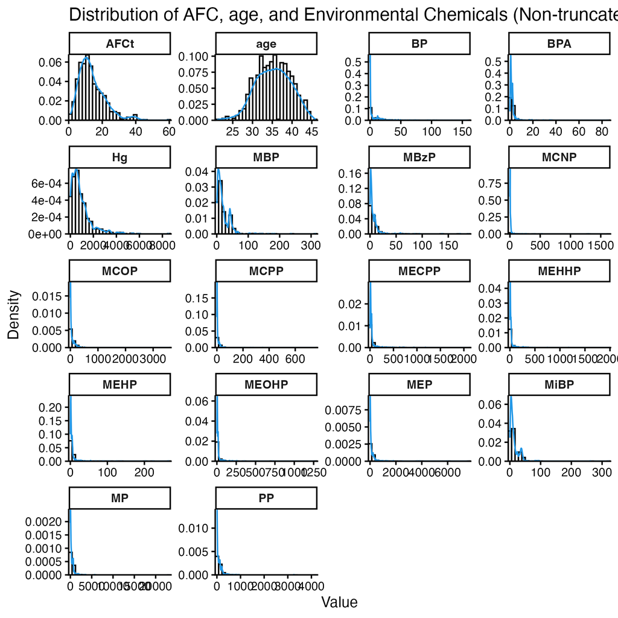

Distribution of environmental chemical exposures without truncation

This figure displays the distributions of AFC, age, and the 16 chemicals as used in all analyses, without any truncation of extreme values.

## 4.2 Environmental Variables Distribution (Truncated)

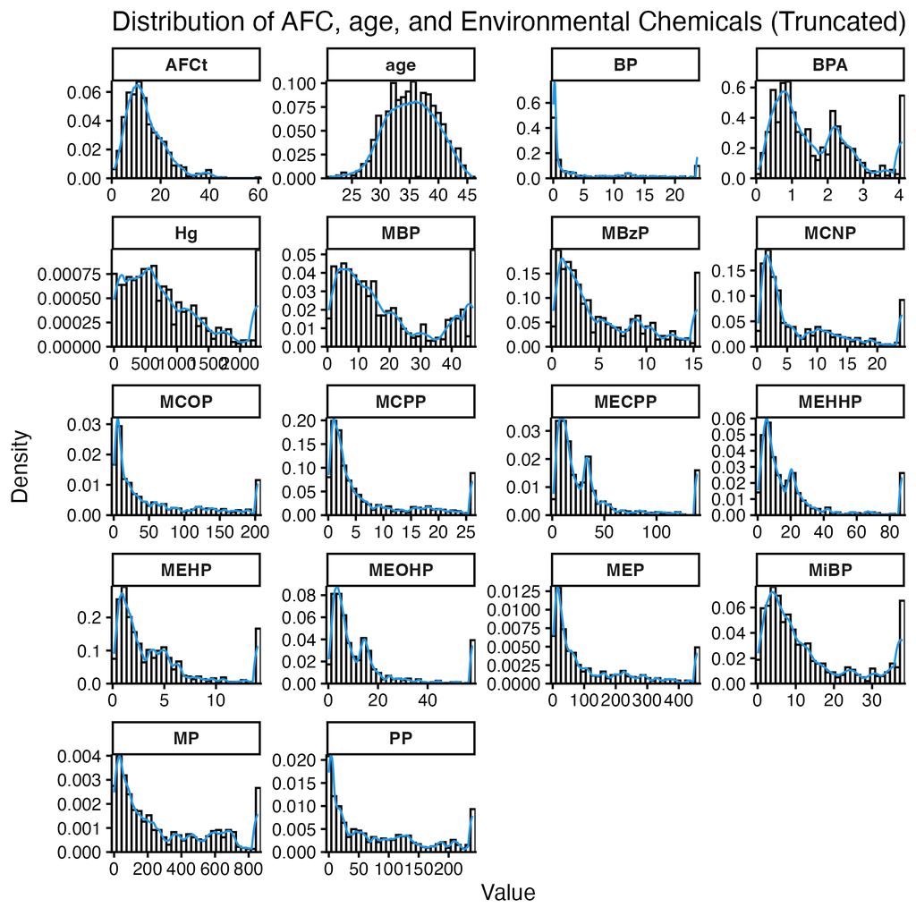

Distribution of environmental chemical exposures with truncation

This figure shows the same distributions **after** capping each chemical at its 92.5th percentile. The capped data are used only for this descriptive comparison.

## 4.3 Outlier Analysis

This subsection presents a detailed examination of multivariate outliers across the chemical exposure space to identify individuals with unusual exposure profiles.

### 4.3.1 Outlier Detection Grid

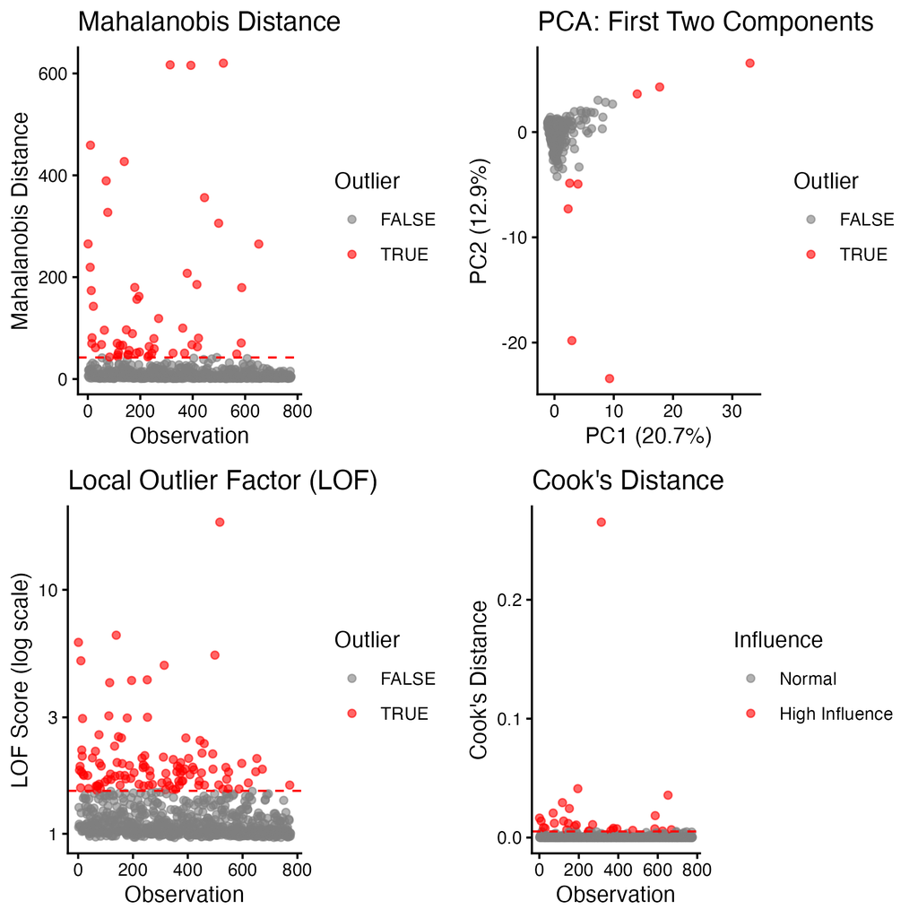

Grid of outlier detection metrics across chemical exposures

### 4.3.2 Outlier Heatmap

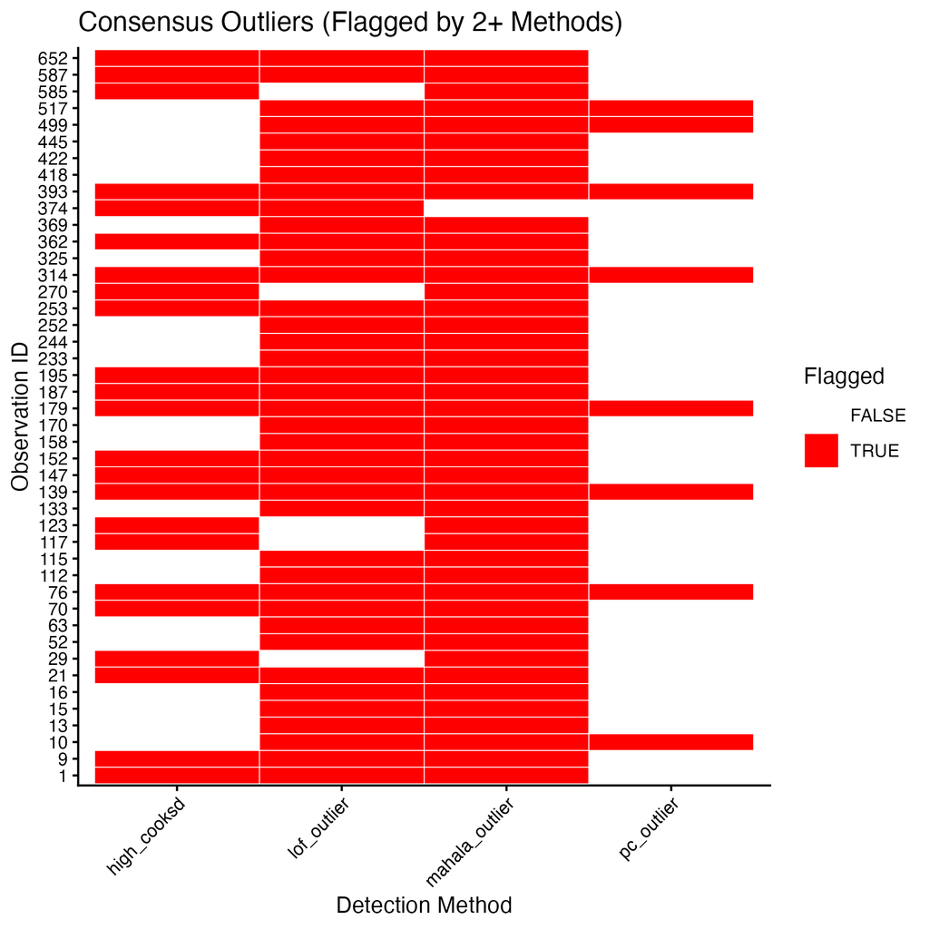

Heatmap of multivariate outlier patterns

### 4.3.3 Identified Outliers

```r
outliers_id <- readRDS(here("output", "outliers_id.rds"))
knitr::kable(outliers_id, caption = "Summary of Identified Outlier Observations")
```

Summary of Identified Outlier Observations

| row_id | AFCt | age | n_flags | mahala_outlier | pc_outlier | lof_outlier | high_cooksd |
| --- | --- | --- | --- | --- | --- | --- | --- |
| 314 | 12 | 37 | 4 | TRUE | TRUE | TRUE | TRUE |
| 393 | 16 | 42 | 4 | TRUE | TRUE | TRUE | TRUE |
| 139 | 8 | 42 | 4 | TRUE | TRUE | TRUE | TRUE |
| 76 | 14 | 41 | 4 | TRUE | TRUE | TRUE | TRUE |
| 179 | 16 | 34 | 4 | TRUE | TRUE | TRUE | TRUE |
| 517 | 13 | 35 | 3 | TRUE | TRUE | TRUE | FALSE |
| 10 | 7 | 40 | 3 | TRUE | TRUE | TRUE | FALSE |
| 70 | 7 | 32 | 3 | TRUE | FALSE | TRUE | TRUE |
| 499 | 7 | 33 | 3 | TRUE | TRUE | TRUE | FALSE |
| 1 | 18 | 40 | 3 | TRUE | FALSE | TRUE | TRUE |
| 652 | 5 | 36 | 3 | TRUE | FALSE | TRUE | TRUE |
| 9 | 11 | 32 | 3 | TRUE | FALSE | TRUE | TRUE |
| 587 | 5 | 38 | 3 | TRUE | FALSE | TRUE | TRUE |
| 195 | 26 | 37 | 3 | TRUE | FALSE | TRUE | TRUE |
| 187 | 6 | 40 | 3 | TRUE | FALSE | TRUE | TRUE |
| 21 | 19 | 36 | 3 | TRUE | FALSE | TRUE | TRUE |
| 362 | 18 | 35 | 3 | TRUE | FALSE | TRUE | TRUE |
| 147 | 24 | 24 | 3 | TRUE | FALSE | TRUE | TRUE |
| 253 | 7 | 36 | 3 | TRUE | FALSE | TRUE | TRUE |
| 152 | 35 | 29 | 3 | TRUE | FALSE | TRUE | TRUE |

This table lists the observations flagged by at least three of the four diagnostics. They were retained in all analyses.

## 4.4 Age-Stratified Associations between Chemicals and AFC (Table S2)

```r
assoc_table <- readRDS(here("output", "association_table_by_age.rds"))
names(assoc_table) <- c("Chemical",
                        "Conditional, age < 35", "Unconditional, age < 35",
                        "Conditional, age ≥ 35", "Unconditional, age ≥ 35")
knitr::kable(assoc_table, caption = "Mean difference in AFC (HC3 standard error) per one-unit increase in the log-transformed chemical concentration, from ordinary least squares models stratified by age group. Conditional models include all 16 chemicals; unconditional models include one chemical at a time.")
```

Mean difference in AFC (HC3 standard error) per one-unit increase in the log-transformed chemical concentration, from ordinary least squares models stratified by age group. Conditional models include all 16 chemicals; unconditional models include one chemical at a time.

| Chemical | Conditional, age < 35 | Unconditional, age < 35 | Conditional, age ≥ 35 | Unconditional, age ≥ 35 |
| --- | --- | --- | --- | --- |
| MBP | -1.47 (0.71) | -0.2 (0.4) | 0.22 (0.5) | -0.05 (0.27) |
| MiBP | 1.08 (0.78) | 0.47 (0.45) | -0.19 (0.42) | -0.15 (0.28) |
| MCNP | -0.26 (0.62) | 0.08 (0.39) | 0.04 (0.38) | -0.14 (0.23) |
| MCOP | 0.97 (0.62) | 0.49 (0.32) | -0.19 (0.37) | -0.15 (0.21) |
| MECPP | -1.06 (1.61) | -0.38 (0.38) | -0.67 (0.72) | -0.46 (0.26) |
| MEHHP | 0.83 (2.23) | -0.27 (0.35) | -0.25 (1.27) | -0.37 (0.24) |
| MEHP | 1.08 (0.65) | 0.22 (0.36) | -0.36 (0.42) | -0.45 (0.22) |
| MEOHP | -0.84 (2.73) | -0.29 (0.36) | 0.64 (1.33) | -0.35 (0.24) |
| MCPP | -0.49 (0.81) | 0.22 (0.39) | 0.17 (0.34) | -0.07 (0.21) |
| MEP | 0.08 (0.45) | 0.09 (0.38) | -0.29 (0.29) | -0.22 (0.21) |
| MBzP | 0.59 (0.51) | 0.35 (0.39) | -0.05 (0.38) | -0.03 (0.27) |
| BPA | 0.19 (0.59) | -0.01 (0.53) | 0.5 (0.34) | 0.26 (0.29) |
| BP | -0.31 (0.32) | -0.07 (0.25) | 0.21 (0.17) | 0.08 (0.15) |
| MP | 0.58 (0.75) | 0.3 (0.32) | 0.29 (0.46) | -0.04 (0.19) |
| PP | -0.04 (0.58) | 0.21 (0.25) | -0.32 (0.35) | -0.12 (0.15) |
| Hg | -0.72 (0.39) | -0.73 (0.37) | -0.04 (0.28) | 0.02 (0.26) |

These are the descriptive associations reported in Table S2 of the manuscript. Chemicals are log-transformed, so each coefficient is the mean difference in AFC for a one-unit increase in log concentration within the age stratum.

# 5 Step 3: Influence Function Score Generation

This section presents results from fitting the algorithms needed for the doubly robust learner. These algorithms include fits for the outcome regression (mu) and propensity score (pi) models using SuperLearner. The influence function scores are then used to construct AIPW scores, which can be averaged to compute the conditional associations and marginal associations defined in the main paper.

## 5.1 Main Scatterplot: AFC vs Age

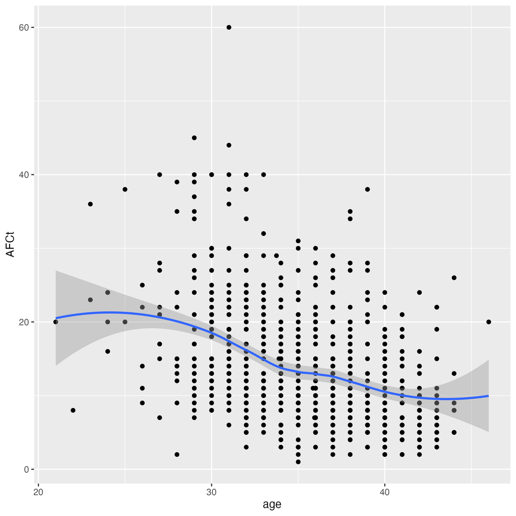

Scatterplot of AFC against age

This scatterplot visualizes the relationship between age (the exposure of interest, in years) and antral follicle count (the outcome) in the study population. The plot provides a visual assessment of the strength and form of the age-AFC association before covariate adjustment and before dichotomizing age at 35 years.

## 5.2 Descriptive Statistics (Table 1)

```r
descriptives_table1 <- readRDS(here("output", "descriptives_table1.rds"))
knitr::kable(descriptives_table1, caption = "Descriptive Statistics of Analysis Sample")
```

Descriptive Statistics of Analysis Sample

| as.numeric(age >= 35) | mean_bmi | mean_gravid | mean_IUI | mean_IVF | mean_AFC |
| --- | --- | --- | --- | --- | --- |
| 0 | 24 | 0.34 | 0.25 | 0.09 | 17 |
| 1 | 25 | 0.54 | 0.32 | 0.19 | 12 |

This table presents selected characteristics of the analysis sample by age group (0 = age < 35 years, 1 = age ≥ 35 years): mean BMI, the proportions gravid, with prior IUI, and with prior IVF, and mean AFC. Table 1 of the manuscript reports the full set of characteristics.

## 5.3 SuperLearner Outcome Model (Mu) Summary

```r
mu_sl_summary <- readRDS(here("output", "mu_sl_summary.rds"))
print(mu_sl_summary$Table)
```

```
                        Algorithm Ave  se Min Max
1                   Super Learner  55 4.1  40  75
2                     Discrete SL  56 4.2  36  76
3                     SL.mean_All  61 4.8  40  89
4                      SL.glm_All  57 4.1  41  73
5                 SL.ranger_1_All  56 4.3  39  81
6                 SL.ranger_2_All  56 4.3  39  81
7                 SL.ranger_3_All  56 4.2  39  80
8                 SL.ranger_4_All  56 4.2  39  80
9                 SL.ranger_5_All  55 4.2  39  80
10                SL.ranger_6_All  55 4.2  39  79
11               SL.xgboost_1_All  71 4.4  50  85
12               SL.xgboost_2_All  70 4.5  47  85
13               SL.xgboost_3_All  71 4.4  50  85
14               SL.xgboost_4_All  70 4.5  47  85
15                SL.glmnet_1_All  56 4.2  37  74
16                SL.glmnet_2_All  54 4.2  36  77
17                SL.glmnet_3_All  54 4.2  36  76
18                SL.glmnet_4_All  54 4.2  36  76
19                SL.glmnet_5_All  54 4.2  36  76
20                SL.glmnet_6_All  54 4.2  36  76
21 SL.glm.interaction_screen.corP  63 4.4  38  78
```

This output summarizes the performance of the SuperLearner ensemble used to estimate the outcome regression function (conditional mean of AFC given covariates). The summary includes algorithm weights and cross-validated performance metrics (cross-validated mean squared error), demonstrating how well the ensemble predicts AFC.

## 5.4 SuperLearner Propensity Score (Pi) Summary

```r
pi_sl_summary <- readRDS(here("output", "pi_sl_summary.rds"))
print(pi_sl_summary$Table)
```

```
                        Algorithm  Ave     se  Min  Max
1                   Super Learner 0.24 0.0050 0.20 0.29
2                     Discrete SL 0.24 0.0045 0.21 0.27
3                     SL.mean_All 0.25 0.0025 0.23 0.26
4                      SL.glm_All 0.24 0.0075 0.19 0.31
5                 SL.ranger_1_All 0.24 0.0037 0.21 0.25
6                 SL.ranger_2_All 0.24 0.0037 0.21 0.26
7                 SL.ranger_3_All 0.24 0.0040 0.21 0.26
8                 SL.ranger_4_All 0.24 0.0039 0.21 0.26
9                 SL.ranger_5_All 0.24 0.0041 0.21 0.26
10                SL.ranger_6_All 0.24 0.0040 0.21 0.26
11               SL.xgboost_1_All 0.27 0.0088 0.21 0.34
12               SL.xgboost_2_All 0.27 0.0092 0.21 0.35
13               SL.xgboost_3_All 0.27 0.0088 0.21 0.34
14               SL.xgboost_4_All 0.27 0.0092 0.21 0.35
15                SL.glmnet_1_All 0.24 0.0044 0.20 0.27
16                SL.glmnet_2_All 0.24 0.0046 0.21 0.28
17                SL.glmnet_3_All 0.24 0.0045 0.21 0.27
18                SL.glmnet_4_All 0.24 0.0048 0.21 0.28
19                SL.glmnet_5_All 0.24 0.0047 0.21 0.28
20                SL.glmnet_6_All 0.24 0.0048 0.21 0.28
21 SL.glm.interaction_screen.corP 0.26 0.0082 0.22 0.37
```

This output summarizes the SuperLearner ensemble used to estimate the propensity score (the probability that age ≥ 35 years given covariates). The summary shows which algorithms contribute most to predicting the age indicator and the overall cross-validated performance (cross-validated mean squared error).

## 5.5 Variable Importance Plot

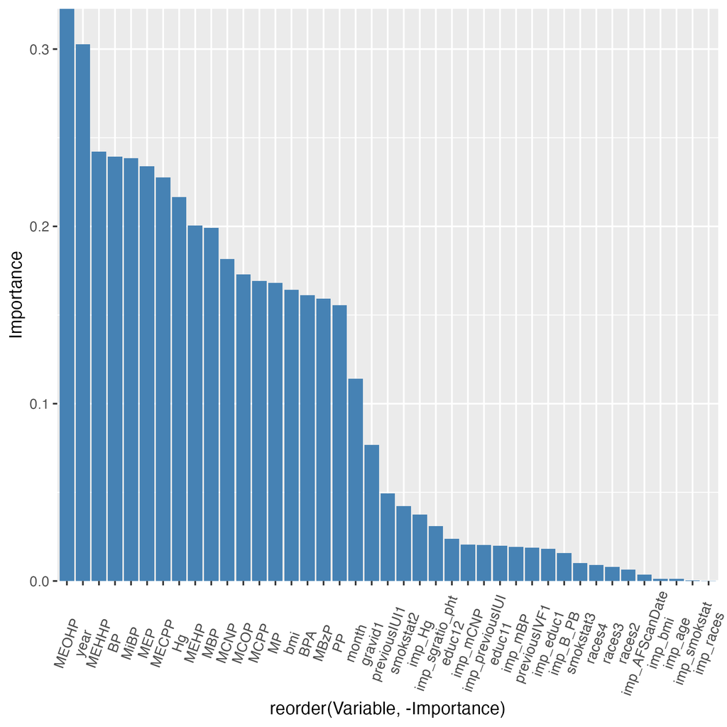

Variable importance from SuperLearner models

This figure displays the relative importance of covariates in predicting antral follicle count, derived from the SuperLearner ensembles. Variable importance measure used specifically is the permutation method.

## 5.6 Propensity Score Overlap

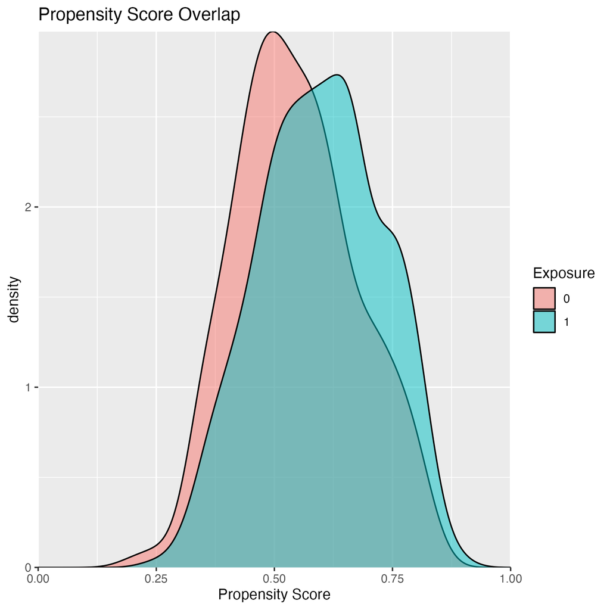

Assessment of propensity score overlap across age distribution

This plot shows the overlap of the SuperLearner propensity scores, displaying the density of predicted probabilities of being aged ≥ 35 years among women aged ≥ 35 (Exposure = 1) and < 35 (Exposure = 0).

## 5.7 Overall Standardized Mean Difference (ψ)

```r
res_ate <- readRDS(here("output", "ate_results.rds"))
knitr::kable(res_ate, caption = "Covariate-standardized mean difference in AFC, age ≥ 35 vs < 35 years, estimated as the mean of the AIPW scores")
```

Covariate-standardized mean difference in AFC, age ≥ 35 vs < 35 years, estimated as the mean of the AIPW scores

|  | estimate | std.err | LCL | UCL |
| --- | --- | --- | --- | --- |
| AIPW with Stacking | -5 | 0.6 | -6.2 | -3.9 |

This table presents the estimated covariate-standardized association between age and AFC (ψ in the manuscript): the difference in mean AFC between women aged ≥ 35 and < 35 years, standardized to the distribution of the covariates included in the models. The row label “AIPW with Stacking” describes the estimator (augmented inverse probability weighting with Super Learner nuisance models). This overall association is the reference line in the figures of Step 4, which examine how the association varies across chemical concentrations.

# 6 Step 4: Modification of the Age-AFC Association by Environmental Chemicals

This section presents the main results, examining whether and how the age-AFC association varies across concentrations of the 16 chemicals. We use best linear projections of the AIPW scores on the log-transformed chemicals to screen for modification, and then plot the conditional association τ(x) as a function of each chemical, linearly for all chemicals and with a cross-validated smoother for the chemicals selected by the projections.

## 6.1 Best Linear Projection Results

```r
table2 <- readRDS(here("output", "linear_projection_output.rds"))
knitr::kable(table2, caption = "Best linear projection of the AIPW scores on the log-transformed chemicals: unconditional (one chemical at a time) and conditional (all 16 chemicals) models with HC3 standard errors")
```

Best linear projection of the AIPW scores on the log-transformed chemicals: unconditional (one chemical at a time) and conditional (all 16 chemicals) models with HC3 standard errors

| Type | term | estimate | std.error | statistic | p.value |
| --- | --- | --- | --- | --- | --- |
| unconditional | MBP | -0.04 | 0.56 | -0.06 | 0.95 |
| unconditional | MiBP | -0.94 | 0.59 | -1.60 | 0.11 |
| unconditional | MCNP | -0.13 | 0.46 | -0.29 | 0.77 |
| unconditional | MCOP | -0.70 | 0.40 | -1.74 | 0.08 |
| unconditional | MECPP | -0.04 | 0.52 | -0.07 | 0.94 |
| unconditional | MEHHP | 0.00 | 0.49 | -0.01 | 0.99 |
| unconditional | MEHP | -0.45 | 0.44 | -1.02 | 0.31 |
| unconditional | MEOHP | -0.04 | 0.48 | -0.08 | 0.93 |
| unconditional | MCPP | -0.43 | 0.45 | -0.96 | 0.34 |
| unconditional | MEP | -0.32 | 0.45 | -0.71 | 0.48 |
| unconditional | MBzP | -0.52 | 0.53 | -1.00 | 0.32 |
| unconditional | BPA | 0.36 | 0.62 | 0.57 | 0.57 |
| unconditional | BP | 0.26 | 0.30 | 0.86 | 0.39 |
| unconditional | MP | -0.27 | 0.38 | -0.72 | 0.47 |
| unconditional | PP | -0.29 | 0.29 | -0.99 | 0.32 |
| unconditional | Hg | 1.04 | 0.49 | 2.10 | 0.04 |
| conditional | MBP | 1.48 | 0.96 | 1.54 | 0.13 |
| conditional | MiBP | -1.49 | 0.89 | -1.67 | 0.10 |
| conditional | MCNP | 0.36 | 0.69 | 0.52 | 0.60 |
| conditional | MCOP | -0.91 | 0.64 | -1.42 | 0.16 |
| conditional | MECPP | 0.42 | 1.57 | 0.27 | 0.79 |
| conditional | MEHHP | 0.39 | 2.71 | 0.14 | 0.89 |
| conditional | MEHP | -1.24 | 0.76 | -1.62 | 0.11 |
| conditional | MEOHP | -0.09 | 2.92 | -0.03 | 0.97 |
| conditional | MCPP | 0.23 | 0.67 | 0.35 | 0.73 |
| conditional | MEP | -0.30 | 0.54 | -0.56 | 0.58 |
| conditional | MBzP | -0.52 | 0.69 | -0.76 | 0.45 |
| conditional | BPA | 0.56 | 0.67 | 0.83 | 0.40 |
| conditional | BP | 0.52 | 0.37 | 1.40 | 0.16 |
| conditional | MP | -0.01 | 0.85 | -0.01 | 0.99 |
| conditional | PP | -0.40 | 0.66 | -0.60 | 0.55 |
| conditional | Hg | 0.94 | 0.51 | 1.83 | 0.07 |

This table presents the linear projections of the AIPW scores on each log-transformed chemical. Large and precise coefficients indicate that the age-AFC association varies as a function of the chemical concentration. The best linear projection provides valid inference about the linear summary even when the underlying function τ(x) is not linear, provided one keeps in mind that the coefficients describe a projection and not the function itself.

## 6.2 Wald Test Statistics from the Linear Projections (Figure 1)

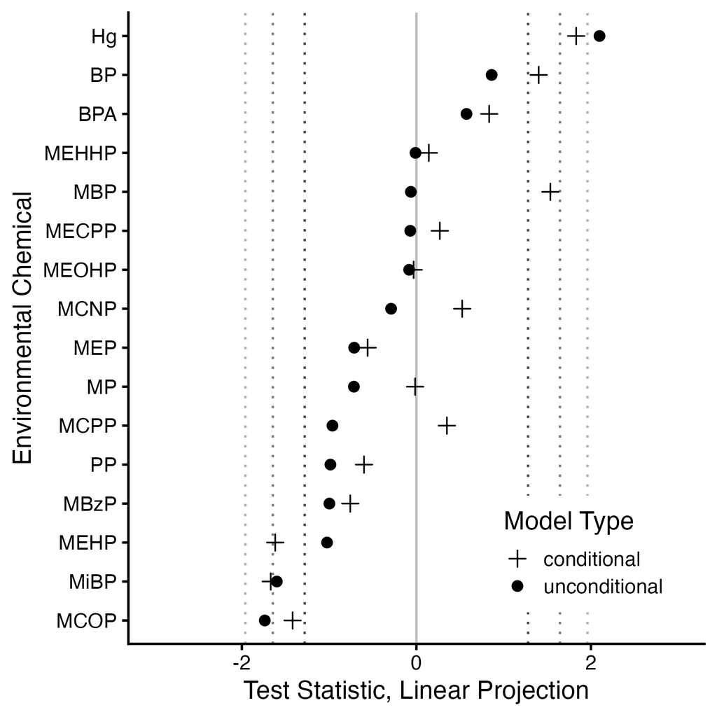

Wald test statistics from the linear projection models, by chemical

This plot shows the Wald test statistics (coefficient divided by HC3 standard error) from the linear projections, one point per chemical and model. Filled circles are unconditional models (one chemical at a time) and plus signs are conditional models (all chemicals together). Chemicals are ordered by the unconditional statistic. The dotted vertical reference lines are drawn at ±1.28, ±1.645, and ±1.96. Negative values indicate that higher concentrations accompany a more negative age-AFC difference; positive values indicate a less negative difference.

## 6.3 Conditional Association Functions by Chemical

### 6.3.1 Linear Functions (All 16 Chemicals)

[figure not shown]

Linear association functions for all 16 environmental chemicals

### 6.3.2 Cross-Validated LOESS Functions for the Selected Phthalates (Figure 2)

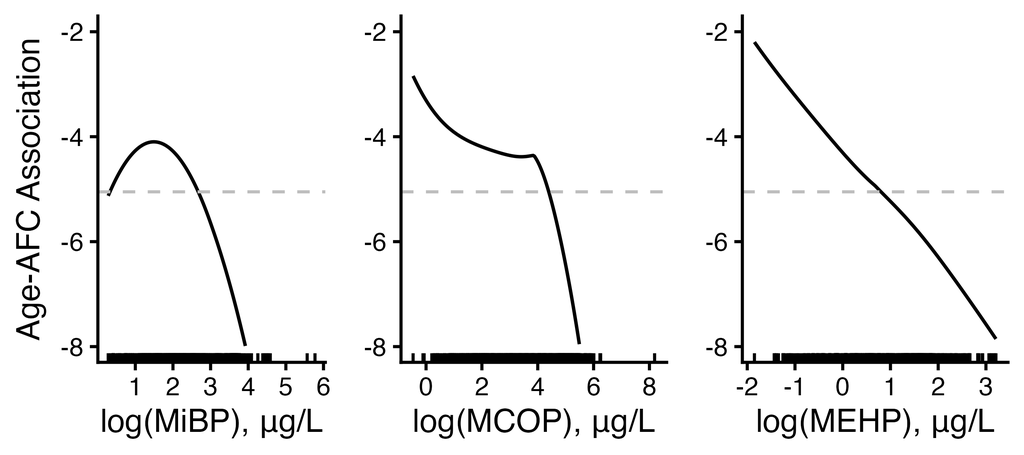

Cross-validated LOESS association functions for MiBP, MCOP, and MEHP